# Financial Econometrics II

Matias Palmunen

2026-01-20

## Introduction

This document contains analysis for Financial Econometrics II.

## Load Libraries

```r
# Install packages if they don't exist
required_packages <- c("tidyverse", "haven", "knitr", "kableExtra", "here")
new_packages <- required_packages[!(required_packages %in% installed.packages()[,"Package"])]
if(length(new_packages)) install.packages(new_packages)


packages <- c("bacondecomp", "fixest", "did", "did2s", "didimputation")
for (pkg in packages) {
  if (!require(pkg, character.only = TRUE, quietly = TRUE)) {
    install.packages(pkg, repos = "https://cloud.r-project.org")
    library(pkg, character.only = TRUE)
  }
}


# Load libraries
library(tidyverse)
library(haven)
library(knitr)
library(kableExtra)
library(here)
library(ggplot2)
```

## Helper Functions

```r
# Function to save figures for LaTeX with proper sizing
save_figure <- function(plot, filename, width = 6.5, height = 4) {
  # Ensure the figures directory exists
  fig_dir <- here::here("tex_report_2", "figures")
  if (!dir.exists(fig_dir)) {
    dir.create(fig_dir, recursive = TRUE)
  }

  # Construct the full path
  filepath <- file.path(fig_dir, filename)

  # Save the plot
  ggplot2::ggsave(
    filename = filepath,
    plot = plot,
    width = width,
    height = height,
    units = "in",
    dpi = 300,
    device = "pdf"
  )

  cat("Figure saved to:", filepath, "\n")
}

# Function to save tables in LaTeX tabular format
save_table <- function(data, filename, caption = "", label = "") {
  # Ensure the tables directory exists
  tables_dir <- here::here("tex_report_2", "tables")
  if (!dir.exists(tables_dir)) {
    dir.create(tables_dir, recursive = TRUE)
  }

  # Construct the full path
  filepath <- file.path(tables_dir, filename)

  # Convert to LaTeX table using kable
  latex_table <- kable(data,
                       format = "latex",
                       booktabs = TRUE,
                       caption = caption,
                       label = label)

  # Write to file
  writeLines(as.character(latex_table), filepath)

  cat("Table saved to:", filepath, "\n")
}
```

## Load Data

```r
# Load data from the data folder
data_path <- here::here("data", "PS2_data.dta")
ps2_data <- read_dta(data_path) %>%
  as_tibble()

head(ps2_data)
```

```
## # A tibble: 6 × 5
##   state   id_num  year hityear ln_policies
##   <chr>    <dbl> <dbl>   <dbl>       <dbl>
## 1 ALABAMA  10010  1990       0       -5.65
## 2 ALABAMA  10010  1991       0       -5.68
## 3 ALABAMA  10010  1992       0       -5.71
## 4 ALABAMA  10010  1993       0       -5.73
## 5 ALABAMA  10010  1994       0       -5.73
## 6 ALABAMA  10010  1995       0       -5.73
```

## Problem (b): Event Study Graph

### Data Preparation

```r
# Load the data
data_path <- here::here("data", "PS2_data.dta")
ps2_data <- read_dta(data_path) %>%
  as_tibble()

# Examine the data structure
cat("Dataset dimensions:", nrow(ps2_data), "rows ×", ncol(ps2_data), "columns\n\n")
```

```
## Dataset dimensions: 126342 rows × 5 columns
```

```r
# Show first few rows
ps2_data %>%
  head(10) %>%
  kable(caption = "First 10 rows of PS2 data")
```

First 10 rows of PS2 data

| state | id_num | year | hityear | ln_policies |
| --- | --- | --- | --- | --- |
| ALABAMA | 10010 | 1990 | 0 | -5.650734 |
| ALABAMA | 10010 | 1991 | 0 | -5.680172 |
| ALABAMA | 10010 | 1992 | 0 | -5.712081 |
| ALABAMA | 10010 | 1993 | 0 | -5.726848 |
| ALABAMA | 10010 | 1994 | 0 | -5.730100 |
| ALABAMA | 10010 | 1995 | 0 | -5.730100 |
| ALABAMA | 10010 | 1996 | 0 | -5.041811 |
| ALABAMA | 10010 | 1997 | 0 | -5.054652 |
| ALABAMA | 10010 | 1998 | 0 | -5.056246 |
| ALABAMA | 10010 | 1999 | 0 | -5.048252 |

```r
# Check for communities that experienced floods
flood_summary <- ps2_data %>%
  group_by(id_num) %>%
  summarize(
    num_floods = sum(hityear, na.rm = TRUE),
    flood_year = ifelse(any(hityear == 1), year[which(hityear == 1)[1]], NA)
  )

# Communities with exactly one flood
treated_communities <- flood_summary %>%
  filter(num_floods == 1)

# Never-treated communities
never_treated <- flood_summary %>%
  filter(num_floods == 0)

# Display summary statistics
tibble(
  Category = c("Communities with exactly 1 flood", "Never-treated communities", "Total communities"),
  Count = c(nrow(treated_communities), nrow(never_treated), nrow(flood_summary))
) %>%
  kable(caption = "Community Treatment Status Summary")
```

Community Treatment Status Summary

| Category | Count |
| --- | --- |
| Communities with exactly 1 flood | 3092 |
| Never-treated communities | 3927 |
| Total communities | 7019 |

### Create Relative Time Variables

```r
# Install and load packages


# Create treatment year variable
ps2_data <- ps2_data %>%
  group_by(id_num) %>%
  mutate(
    treatment_year = ifelse(any(hityear == 1),
                           year[which(hityear == 1)[1]],
                           Inf),
    # Relative time to treatment
    rel_time = year - treatment_year,
    # Post treatment indicator
    post = as.numeric(year >= treatment_year),
    # Never treated indicator
    never_treated = is.infinite(treatment_year)
  ) %>%
  ungroup()

# Check distribution of treatment timing
treatment_timing <- ps2_data %>%
  filter(!is.infinite(treatment_year)) %>%
  distinct(id_num, treatment_year) %>%
  count(treatment_year) %>%
  rename(`Treatment Year` = treatment_year, `Number of Communities` = n)

treatment_timing %>%
  kable(caption = "Distribution of Treatment Timing")
```

Distribution of Treatment Timing

| Treatment Year | Number of Communities |
| --- | --- |
| 1990 | 102 |
| 1991 | 74 |
| 1992 | 21 |
| 1993 | 282 |
| 1994 | 17 |
| 1995 | 117 |
| 1996 | 308 |
| 1997 | 230 |
| 1998 | 42 |
| 1999 | 208 |
| 2000 | 59 |
| 2001 | 106 |
| 2002 | 158 |
| 2003 | 104 |
| 2004 | 466 |
| 2005 | 198 |
| 2006 | 159 |
| 2007 | 441 |

### Event Study Regression

Following Baker et al. (2022) recommendations on binning, I’ll create binned endpoints for the event study. - Use 6 bins to capture dynamics while avoiding sparse data issues.

```r
# Create relative time dummies with binning
# Bin at -6 and earlier, and +6 and later
ps2_data <- ps2_data %>%
  mutate(
    rel_time_binned = case_when(
      is.infinite(treatment_year) ~ NA_real_,
      rel_time <= -6 ~ -6,
      rel_time >= 6 ~ 6,
      TRUE ~ rel_time
    )
  )

# Create dummy variables for each relative time (omit -1 as base period)
rel_time_range <- -6:6
rel_time_range <- rel_time_range[rel_time_range != -1]  # Omit -1 as base

# Event study regression with community and year fixed effects
# Using fixest for two-way fixed effects
event_study_formula <- as.formula(paste(
  "ln_policies ~ ",
  paste0("i(rel_time_binned, ref = -1)"),
  " | id_num + year"
))

event_study_model <- feols(
  event_study_formula,
  data = ps2_data %>% filter(!is.infinite(treatment_year)),
  cluster = ~ state  # Cluster by state as in Gallagher (2014)
)

# Display model summary
broom::tidy(event_study_model, conf.int = TRUE) %>%
  mutate(across(where(is.numeric), ~round(., 4))) %>%
  kable(caption = "Event Study Regression Results")
```

Event Study Regression Results

| term | estimate | std.error | statistic | p.value | conf.low | conf.high |
| --- | --- | --- | --- | --- | --- | --- |
| rel_time_binned::-6 | -0.0145 | 0.0319 | -0.4541 | 0.6519 | -0.0787 | 0.0497 |
| rel_time_binned::-5 | -0.0072 | 0.0251 | -0.2877 | 0.7748 | -0.0577 | 0.0432 |
| rel_time_binned::-4 | -0.0078 | 0.0205 | -0.3785 | 0.7067 | -0.0490 | 0.0335 |
| rel_time_binned::-3 | -0.0092 | 0.0136 | -0.6754 | 0.5027 | -0.0364 | 0.0181 |
| rel_time_binned::-2 | -0.0084 | 0.0080 | -1.0556 | 0.2965 | -0.0245 | 0.0076 |
| rel_time_binned::0 | 0.1136 | 0.0151 | 7.5215 | 0.0000 | 0.0832 | 0.1440 |
| rel_time_binned::1 | 0.1277 | 0.0239 | 5.3362 | 0.0000 | 0.0796 | 0.1758 |
| rel_time_binned::2 | 0.1524 | 0.0283 | 5.3884 | 0.0000 | 0.0955 | 0.2094 |
| rel_time_binned::3 | 0.1351 | 0.0315 | 4.2897 | 0.0001 | 0.0718 | 0.1985 |
| rel_time_binned::4 | 0.1077 | 0.0303 | 3.5588 | 0.0009 | 0.0468 | 0.1685 |
| rel_time_binned::5 | 0.0859 | 0.0355 | 2.4219 | 0.0194 | 0.0145 | 0.1573 |
| rel_time_binned::6 | 0.0466 | 0.0517 | 0.9014 | 0.3720 | -0.0574 | 0.1506 |

```r
# Extract coefficients for plotting
event_study_coefs <- broom::tidy(event_study_model, conf.int = TRUE) %>%
  filter(grepl("rel_time", term)) %>%
  mutate(
    rel_time = as.numeric(gsub(".*::([-0-9]+).*", "\\1", term))
  ) %>%
  # Add the omitted period (-1) with coefficient 0
  bind_rows(
    tibble(
      term = "rel_time_binned::-1",
      estimate = 0,
      std.error = 0,
      statistic = NA,
      p.value = NA,
      conf.low = 0,
      conf.high = 0,
      rel_time = -1
    )
  ) %>%
  arrange(rel_time)
```

### Event Study Plot

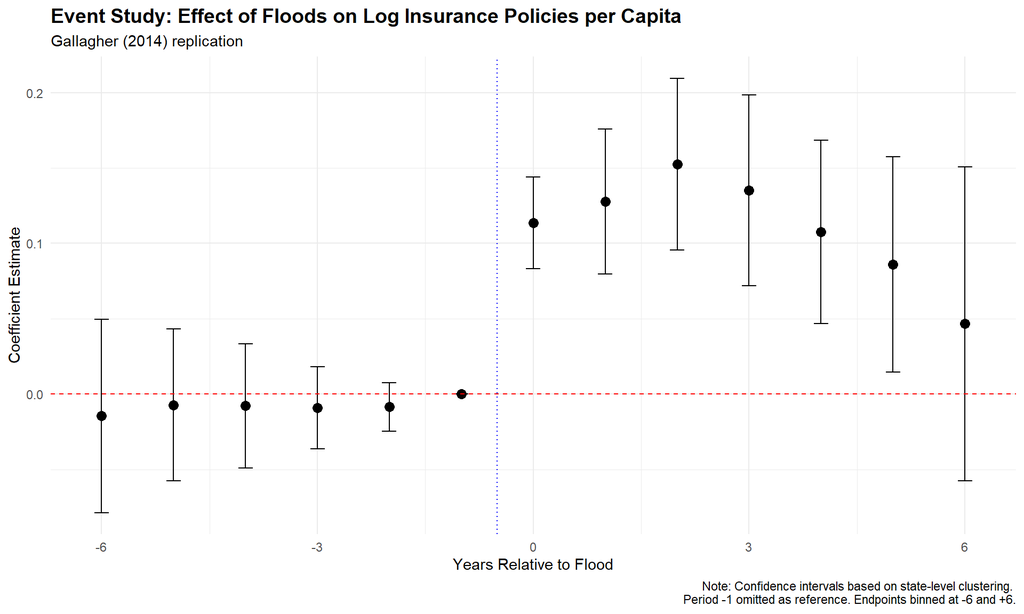

```r
# Create event study plot
ggplot(event_study_coefs, aes(x = rel_time, y = estimate)) +
  geom_point(size = 3) +
  geom_errorbar(aes(ymin = conf.low, ymax = conf.high), width = 0.2) +
  geom_hline(yintercept = 0, linetype = "dashed", color = "red") +
  geom_vline(xintercept = -0.5, linetype = "dotted", color = "blue") +
  labs(
    title = "Event Study: Effect of Floods on Log Insurance Policies per Capita",
    subtitle = "Gallagher (2014) replication",
    x = "Years Relative to Flood",
    y = "Coefficient Estimate",
    caption = "Note: Confidence intervals based on state-level clustering. \nPeriod -1 omitted as reference. Endpoints binned at -6 and +6."
  ) +
  theme_minimal() +
  theme(
    plot.title = element_text(face = "bold", size = 14),
    plot.subtitle = element_text(size = 11),
    axis.title = element_text(size = 11)
  )
```

### Extended Event Study Plot (Binning at ±11)

- This binning is similar to the paper

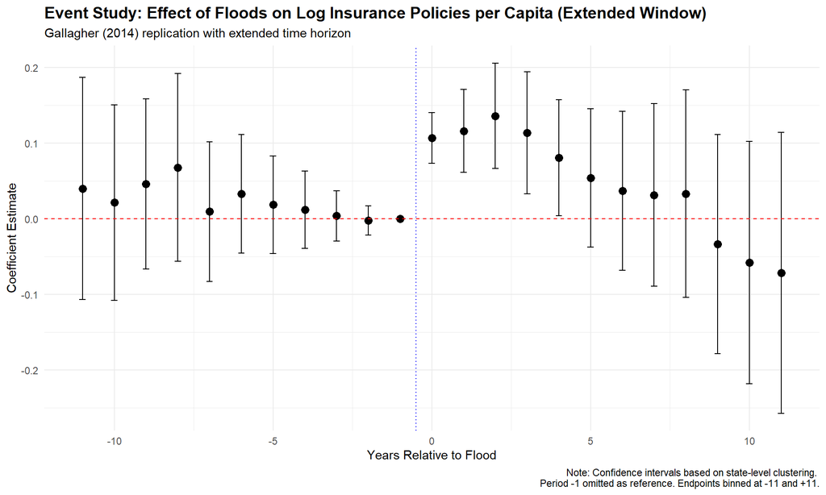

```r
# Create relative time dummies with extended binning
# Bin at -11 and earlier, and +11 and later
ps2_data <- ps2_data %>%
  mutate(
    rel_time_binned_ext = case_when(
      is.infinite(treatment_year) ~ NA_real_,
      rel_time <= -11 ~ -11,
      rel_time >= 11 ~ 11,
      TRUE ~ rel_time
    )
  )

# Event study regression with extended time window
event_study_formula_ext <- as.formula(paste(
  "ln_policies ~ ",
  paste0("i(rel_time_binned_ext, ref = -1)"),
  " | id_num + year"
))

event_study_model_ext <- feols(
  event_study_formula_ext,
  data = ps2_data %>% filter(!is.infinite(treatment_year)),
  cluster = ~ state
)

# Extract coefficients for plotting
event_study_coefs_ext <- broom::tidy(event_study_model_ext, conf.int = TRUE) %>%
  filter(grepl("rel_time", term)) %>%
  mutate(
    rel_time = as.numeric(gsub(".*::([-0-9]+).*", "\\1", term))
  ) %>%
  # Add the omitted period (-1) with coefficient 0
  bind_rows(
    tibble(
      term = "rel_time_binned_ext::-1",
      estimate = 0,
      std.error = 0,
      statistic = NA,
      p.value = NA,
      conf.low = 0,
      conf.high = 0,
      rel_time = -1
    )
  ) %>%
  arrange(rel_time)

# Create extended event study plot
ggplot(event_study_coefs_ext, aes(x = rel_time, y = estimate)) +
  geom_point(size = 3) +
  geom_errorbar(aes(ymin = conf.low, ymax = conf.high), width = 0.2) +
  geom_hline(yintercept = 0, linetype = "dashed", color = "red") +
  geom_vline(xintercept = -0.5, linetype = "dotted", color = "blue") +
  labs(
    title = "Event Study: Effect of Floods on Log Insurance Policies per Capita (Extended Window)",
    subtitle = "Gallagher (2014) replication with extended time horizon",
    x = "Years Relative to Flood",
    y = "Coefficient Estimate",
    caption = "Note: Confidence intervals based on state-level clustering. \nPeriod -1 omitted as reference. Endpoints binned at -11 and +11."
  ) +
  theme_minimal() +
  theme(
    plot.title = element_text(face = "bold", size = 14),
    plot.subtitle = element_text(size = 11),
    axis.title = element_text(size = 11)
  )
```

### (b)(i) Interpretation of Plotted Coefficients

Key interpretations:

1. **Pre-treatment coefficients (rel_time < 0)**: These should be close to zero and statistically insignificant if the parallel trends assumption holds. They test whether treated and control communities had similar trends before the flood.
2. **Post-treatment coefficients (rel_time >= 0)**: These capture the causal effect of experiencing a flood on insurance take-up. We expect positive coefficients if floods increase awareness and perceived risk.
3. **Dynamic effects**: The pattern across post-treatment periods shows how the effect evolves over time - whether it’s immediate, grows, or fades.
4. **Magnitude**: Since the outcome is in logs, coefficients can be interpreted approximately as percentage changes (exact: exp(β) - 1).

### (b)(ii) Standard Error Clustering

```r
# Gallagher (2014) clusters at the state level
# Let's compare different clustering approaches

# State-level clustering (Gallagher's choice)
model_state_cluster <- feols(
  event_study_formula,
  data = ps2_data %>% filter(!is.infinite(treatment_year)),
  cluster = ~ state
)

# Community-level clustering
model_community_cluster <- feols(
  event_study_formula,
  data = ps2_data %>% filter(!is.infinite(treatment_year)),
  cluster = ~ id_num
)

# Two-way clustering (state and year)
model_twoway_cluster <- feols(
  event_study_formula,
  data = ps2_data %>% filter(!is.infinite(treatment_year)),
  cluster = ~ state + year
)

# Compare standard errors across different clustering approaches
bind_rows(
  broom::tidy(model_state_cluster, conf.int = TRUE) %>% mutate(Clustering = "State"),
  broom::tidy(model_community_cluster, conf.int = TRUE) %>% mutate(Clustering = "Community"),
  broom::tidy(model_twoway_cluster, conf.int = TRUE) %>% mutate(Clustering = "State + Year")
) %>%
  select(Clustering, term, estimate, std.error, p.value) %>%
  mutate(across(c(estimate, std.error, p.value), ~round(., 4))) %>%
  filter(term != "(Intercept)") %>%
  head(15) %>%
  kable(caption = "Comparison of Standard Errors by Clustering Method (Selected Coefficients)",
        col.names = c("Clustering", "Term", "Estimate", "Std. Error", "P-value"))
```

Comparison of Standard Errors by Clustering Method (Selected Coefficients)

| Clustering | Term | Estimate | Std. Error | P-value |
| --- | --- | --- | --- | --- |
| State | rel_time_binned::-6 | -0.0145 | 0.0319 | 0.6519 |
| State | rel_time_binned::-5 | -0.0072 | 0.0251 | 0.7748 |
| State | rel_time_binned::-4 | -0.0078 | 0.0205 | 0.7067 |
| State | rel_time_binned::-3 | -0.0092 | 0.0136 | 0.5027 |
| State | rel_time_binned::-2 | -0.0084 | 0.0080 | 0.2965 |
| State | rel_time_binned::0 | 0.1136 | 0.0151 | 0.0000 |
| State | rel_time_binned::1 | 0.1277 | 0.0239 | 0.0000 |
| State | rel_time_binned::2 | 0.1524 | 0.0283 | 0.0000 |
| State | rel_time_binned::3 | 0.1351 | 0.0315 | 0.0001 |
| State | rel_time_binned::4 | 0.1077 | 0.0303 | 0.0009 |
| State | rel_time_binned::5 | 0.0859 | 0.0355 | 0.0194 |
| State | rel_time_binned::6 | 0.0466 | 0.0517 | 0.3720 |
| Community | rel_time_binned::-6 | -0.0145 | 0.0177 | 0.4134 |
| Community | rel_time_binned::-5 | -0.0072 | 0.0136 | 0.5953 |
| Community | rel_time_binned::-4 | -0.0078 | 0.0113 | 0.4915 |

**Comments on Clustering Choice:**

Gallagher (2014) clusters standard errors at the state level. This choice is appropriate because:

1. **Geographic correlation**: Flood experiences and insurance decisions may be correlated within states due to common regulations, insurance markets, and weather patterns.
2. **Treatment variation**: The treatment (floods) likely varies at a level between individual communities and states, so state-level clustering is conservative.
3. **Bertrand et al. (2004) guidance**: With panel data and treatment that varies at the state-year level, clustering at the state level accounts for serial correlation and within-state correlation.

**My assessment**: State-level clustering is appropriate and conservative. Alternative approaches could include: - Two-way clustering (state and year) to account for common time shocks - Community-level clustering if we believe communities are independent, but this would likely understate standard errors

I would make the same choice as Gallagher for the main results, but might show robustness to two-way clustering.

## Problem (c): Bacon-Goodman Decomposition

```r
# Prepare data for Bacon decomposition
# Need a binary treatment variable (ever treated)
# Include both treated and never-treated units
bacon_data <- ps2_data %>%
  mutate(
    treat_year = ifelse(is.infinite(treatment_year), 0, treatment_year),
    treated = post
  )

# Check if panel is balanced and balance it if needed
panel_structure <- bacon_data %>%
  group_by(id_num) %>%
  summarize(n_periods = n(), .groups = 'drop')

# Keep only units that appear in all periods
max_periods <- max(panel_structure$n_periods)
balanced_ids <- panel_structure %>%
  filter(n_periods == max_periods) %>%
  pull(id_num)

bacon_data_balanced <- bacon_data %>%
  filter(id_num %in% balanced_ids)

# Display panel balance information
tibble(
  Metric = c("Original panel size", "Balanced panel size", "Number of units"),
  Value = c(nrow(bacon_data), nrow(bacon_data_balanced), length(balanced_ids))
) %>%
  kable(caption = "Panel Structure for Bacon Decomposition")
```

Panel Structure for Bacon Decomposition

| Metric | Value |
| --- | --- |
| Original panel size | 126342 |
| Balanced panel size | 126342 |
| Number of units | 7019 |

```r
# For computational feasibility, sample units if needed
set.seed(42)
if (length(balanced_ids) > 1000) {
  sampled_ids <- sample(balanced_ids, 1000)
  bacon_data_final <- bacon_data_balanced %>%
    filter(id_num %in% sampled_ids)
  cat("Sampling to", length(sampled_ids), "units for computational feasibility\n")
} else {
  bacon_data_final <- bacon_data_balanced
}
```

```
## Sampling to 1000 units for computational feasibility
```

```r
# Run Bacon decomposition
# Note: bacon requires a balanced panel and specific data structure
bacon_decomp <- bacon(
  ln_policies ~ treated,
  data = bacon_data_final,
  id_var = "id_num",
  time_var = "year"
)
```

```
##                       type  weight avg_est
## 1 Earlier vs Later Treated 0.16129 0.13114
## 2  Later vs Always Treated 0.01287 0.08410
## 3 Later vs Earlier Treated 0.09887 0.20172
## 4     Treated vs Untreated 0.72697 0.16532
```

```r
# Summarize decomposition
bacon_decomp %>%
  as_tibble() %>%
  group_by(type) %>%
  summarise(
    `N Comparisons` = n(),
    `Total Weight` = sum(weight),
    `Avg Estimate` = mean(estimate),
    .groups = 'drop'
  ) %>%
  mutate(across(where(is.numeric), ~round(., 4))) %>%
  kable(caption = "Bacon-Goodman Decomposition Summary")
```

Bacon-Goodman Decomposition Summary

| type | N Comparisons | Total Weight | Avg Estimate |
| --- | --- | --- | --- |
| Earlier vs Later Treated | 120 | 0.1613 | 0.1392 |
| Later vs Always Treated | 16 | 0.0129 | 0.1107 |
| Later vs Earlier Treated | 120 | 0.0989 | 0.1275 |
| Treated vs Untreated | 16 | 0.7270 | 0.1777 |

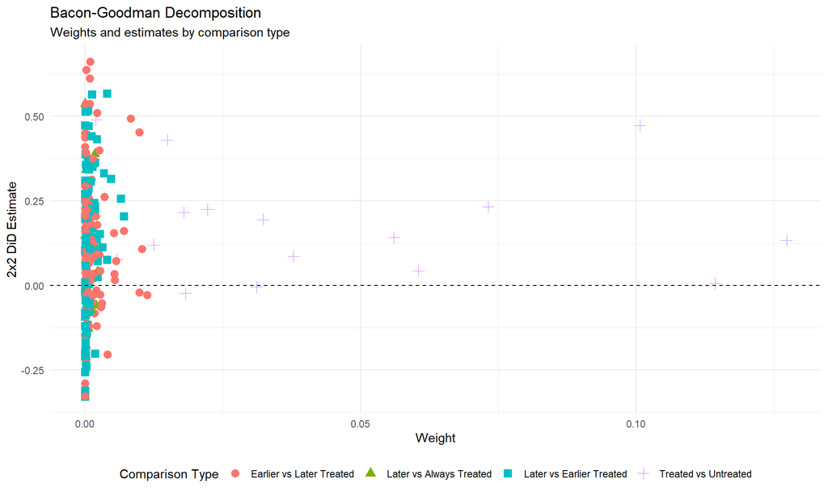

```r
# Visualize decomposition
ggplot(bacon_decomp, aes(x = weight, y = estimate, shape = type, color = type)) +
  geom_point(size = 3) +
  geom_hline(yintercept = 0, linetype = "dashed") +
  labs(
    title = "Bacon-Goodman Decomposition",
    subtitle = "Weights and estimates by comparison type",
    x = "Weight",
    y = "2x2 DiD Estimate",
    shape = "Comparison Type",
    color = "Comparison Type"
  ) +
  theme_minimal() +
  theme(legend.position = "bottom")
```

```r
# Calculate aggregate statistics
bacon_summary <- bacon_decomp %>%
  group_by(type) %>%
  summarize(
    total_weight = sum(weight),
    avg_estimate = weighted.mean(estimate, weight),
    n_comparisons = n(),
    .groups = 'drop'
  )

print(bacon_summary)
```

```
## # A tibble: 4 × 4
##   type                     total_weight avg_estimate n_comparisons
##   <chr>                           <dbl>        <dbl>         <int>
## 1 Earlier vs Later Treated       0.161        0.131            120
## 2 Later vs Always Treated        0.0129       0.0841            16
## 3 Later vs Earlier Treated       0.0989       0.202            120
## 4 Treated vs Untreated           0.727        0.165             16
```

### Interpretation of Bacon Decomposition

```r
# Extract late-to-early comparisons
late_to_early_data <- bacon_decomp %>%
  filter(type == "Later vs Earlier Treated") %>%
  filter(!is.na(estimate) & !is.na(weight))

# Check if there are any late-to-early comparisons
if (nrow(late_to_early_data) > 0) {
  late_to_early <- late_to_early_data %>%
    summarize(
      weight = sum(weight, na.rm = TRUE),
      att = sum(estimate * weight, na.rm = TRUE) / sum(weight, na.rm = TRUE),
      .groups = 'drop'
    )

  # Create results table
  results_df <- bind_rows(
    bacon_summary %>% mutate(Category = "By Type"),
    late_to_early %>%
      mutate(type = "Late-to-Early", Category = "Specific") %>%
      rename(total_weight = weight, avg_estimate = att) %>%
      mutate(n_comparisons = NA)
  ) %>%
    select(Category, type, n_comparisons, total_weight, avg_estimate) %>%
    mutate(across(where(is.numeric), ~round(., 4)))

  results_df %>%
    kable(caption = "Bacon Decomposition Results",
          col.names = c("Category", "Type", "N Comparisons", "Total Weight", "Avg Estimate"))
} else {
  bacon_summary %>%
    mutate(across(where(is.numeric), ~round(., 4))) %>%
    kable(caption = "Bacon Decomposition Results (No Late-to-Early Comparisons Found)")

  cat("\n**Note:** No 'Later vs Earlier Treated' comparisons found. This can occur if all treated units are treated at the same time or the sample doesn't include staggered treatment timing.\n")
}
```

Bacon Decomposition Results

[output not shown]

```r
# Display aggregate TWFE estimate
twfe_aggregate <- sum(bacon_decomp$estimate * bacon_decomp$weight, na.rm = TRUE)
tibble(
  Estimate = "Aggregate TWFE",
  Value = round(twfe_aggregate, 4)
) %>%
  kable()
```

| Estimate | Value |
| --- | --- |
| Aggregate TWFE | 0.1624 |

**Interpretation:**

The Bacon-Goodman decomposition reveals potential problems with the standard TWFE approach in staggered DiD settings:

1. **Forbidden comparisons**: The “later vs earlier” comparisons use already-treated units as controls, which is problematic if treatment effects are heterogeneous or time-varying.
2. **Weight on problematic comparisons**: The proportion of weight on late-to-early comparisons indicates how much the TWFE estimator relies on potentially biased comparisons.
3. **Direction of bias**: If treatment effects grow over time, the late-to-early ATT may be biased, potentially even having the wrong sign relative to the true effect.

Following Borusyak et al. (2024), I’ll implement the imputation estimator manually.

```r
# Step 1: Estimate fixed effects using only untreated observations
# Untreated observations are those where post == 0 (not yet treated or never treated)

untreated_data <- ps2_data %>%
  filter(post == 0 | is.infinite(treatment_year))

# Estimate unit and time fixed effects on untreated sample
fe_model_untreated <- feols(
  ln_policies ~ 1 | id_num + year,
  data = untreated_data
)

# Step 2: Extract fixed effects
# Get unit fixed effects (lambda_i)
unit_fes <- fixef(fe_model_untreated)$id_num
# Get time fixed effects (gamma_t)
time_fes <- fixef(fe_model_untreated)$year

# Create data frames for merging
unit_fe_df <- tibble(
  id_num = as.numeric(names(unit_fes)),
  lambda_i = as.numeric(unit_fes)
)

time_fe_df <- tibble(
  year = as.numeric(names(time_fes)),
  gamma_t = as.numeric(time_fes)
)

# Step 3: For treated observations, impute counterfactual Y(0)
ps2_data_impute <- ps2_data %>%
  left_join(unit_fe_df, by = "id_num") %>%
  left_join(time_fe_df, by = "year") %>%
  mutate(
    # Imputed counterfactual
    Y_hat_0 = lambda_i + gamma_t,
    # Estimated treatment effect (for treated observations)
    tau_hat = ifelse(post == 1 & !is.infinite(treatment_year),
                     ln_policies - Y_hat_0,
                     NA_real_)
  )

# Display summary statistics of imputed treatment effects
ps2_data_impute %>%
  filter(!is.na(tau_hat)) %>%
  summarise(
    N = n(),
    Mean = mean(tau_hat),
    Median = median(tau_hat),
    SD = sd(tau_hat),
    Min = min(tau_hat),
    Max = max(tau_hat)
  ) %>%
  mutate(across(where(is.numeric) & !N, ~round(., 4))) %>%
  kable(caption = "Summary Statistics of Imputed Treatment Effects (τ̂)")
```

Summary Statistics of Imputed Treatment Effects (τ̂)

| N | Mean | Median | SD | Min | Max |
| --- | --- | --- | --- | --- | --- |
| 20742 | 0.0917 | 0.0506 | 0.6638 | -3.3014 | 4.3497 |

### Event Study Plot with Imputation Estimator

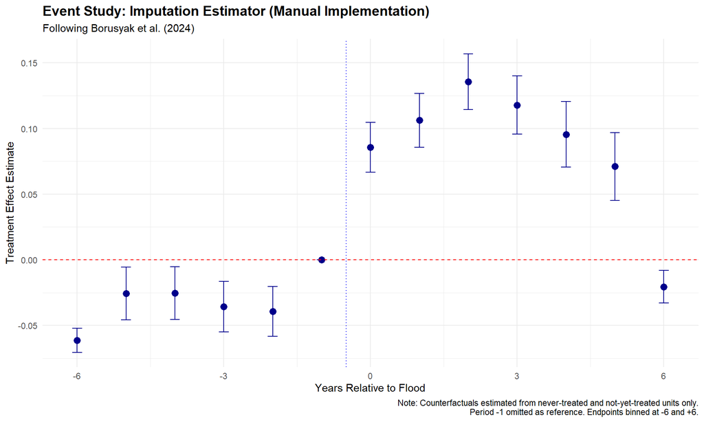

```r
imputation_event_data <- ps2_data_impute %>%
  filter(!is.infinite(treatment_year)) %>%
  mutate(
    tau_hat_all = ln_policies - Y_hat_0,
    rel_time_binned = case_when(
      rel_time <= -6 ~ -6,
      rel_time >= 6 ~ 6,
      TRUE ~ rel_time
    )
  ) %>%
  filter(!is.na(tau_hat_all) & !is.na(rel_time_binned))

rel_time_values <- sort(unique(imputation_event_data$rel_time_binned))
rel_time_values <- rel_time_values[rel_time_values != -1]

imputation_coefs <- map_dfr(rel_time_values, function(t) {
  data_t <- imputation_event_data %>%
    mutate(treat_t = as.numeric(rel_time_binned == t))

  model <- lm(tau_hat_all ~ treat_t, data = data_t)

  broom::tidy(model, conf.int = TRUE) %>%
    filter(term == "treat_t") %>%
    mutate(rel_time = t)
}) %>%
  bind_rows(
    tibble(
      term = "treat_t",
      estimate = 0,
      std.error = 0,
      statistic = NA,
      p.value = NA,
      conf.low = 0,
      conf.high = 0,
      rel_time = -1
    )
  ) %>%
  arrange(rel_time)

ggplot(imputation_coefs, aes(x = rel_time, y = estimate)) +
  geom_point(size = 3, color = "darkblue") +
  geom_errorbar(aes(ymin = conf.low, ymax = conf.high),
                width = 0.2, color = "darkblue") +
  geom_hline(yintercept = 0, linetype = "dashed", color = "red") +
  geom_vline(xintercept = -0.5, linetype = "dotted", color = "blue") +
  labs(
    title = "Event Study: Imputation Estimator (Manual Implementation)",
    subtitle = "Following Borusyak et al. (2024)",
    x = "Years Relative to Flood",
    y = "Treatment Effect Estimate",
    caption = "Note: Counterfactuals estimated from never-treated and not-yet-treated units only.\nPeriod -1 omitted as reference. Endpoints binned at -6 and +6."
  ) +
  theme_minimal() +
  theme(
    plot.title = element_text(face = "bold", size = 14),
    plot.subtitle = element_text(size = 11),
    axis.title = element_text(size = 11)
  )
```

**Interpretation:**

## Problem (e): ATT Estimation and Comparison

### Manual ATT Estimation

```r
# Estimate ATT as simple average of tau_hat for treated observations
att_manual <- ps2_data_impute %>%
  filter(!is.na(tau_hat)) %>%
  summarize(
    ATT = mean(tau_hat),
    SE_incorrect = sd(tau_hat) / sqrt(n()),
    n_treated = n()
  )

# Display manual ATT results
att_manual %>%
  mutate(
    Method = "Manual (Average of τ̂)",
    `ATT Estimate` = round(ATT, 4),
    `SE (Incorrect)` = round(SE_incorrect, 4),
    `N Treated Obs` = n_treated
  ) %>%
  select(Method, `ATT Estimate`, `SE (Incorrect)`, `N Treated Obs`) %>%
  kable(caption = "Manual ATT Estimation Results")
```

Manual ATT Estimation Results

| Method | ATT Estimate | SE (Incorrect) | N Treated Obs |
| --- | --- | --- | --- |
| Manual (Average of τ̂) | 0.0917 | 0.0046 | 20742 |

```r
# Alternative: regress tau_hat on treatment indicator (should give same result)
att_regression <- lm(tau_hat ~ 1, data = ps2_data_impute %>% filter(!is.na(tau_hat)))
```

### ATT Using did2s Package

```r
# Prepare data for did2s package
did_data <- ps2_data %>%
  filter(!is.infinite(treatment_year)) %>%
  mutate(
    first_treat = treatment_year
  )

# Estimate using did2s (Gardner 2021 implementation)
# did2s performs two-stage estimation
did2s_result <- did2s(
  data = did_data,
  yname = "ln_policies",
  first_stage = ~ 0 | id_num + year,
  second_stage = ~ post,
  treatment = "post",
  cluster_var = "state"
)

# Display did2s package results
broom::tidy(did2s_result, conf.int = TRUE) %>%
  mutate(across(where(is.numeric), ~round(., 4))) %>%
  kable(caption = "did2s Package Results (Gardner 2021)")
```

did2s Package Results (Gardner 2021)

| term | estimate | std.error | statistic | p.value | conf.low | conf.high |
| --- | --- | --- | --- | --- | --- | --- |
| post | 0.0756 | 0.0367 | 2.0572 | 0.0397 | 0.0036 | 0.1476 |

```r
# Extract ATT - handle different possible coefficient names
coef_names <- names(coef(did2s_result))
att_package <- if("post" %in% coef_names) {
  coef(did2s_result)["post"]
} else if("post::1" %in% coef_names) {
  coef(did2s_result)["post::1"]
} else {
  coef(did2s_result)[1]
}

# Extract standard error
vcov_mat <- vcov(did2s_result)
se_package <- if("post" %in% rownames(vcov_mat)) {
  sqrt(vcov_mat["post", "post"])
} else if("post::1" %in% rownames(vcov_mat)) {
  sqrt(vcov_mat["post::1", "post::1"])
} else {
  sqrt(vcov_mat[1, 1])
}

# Store package results
cat("\n")
```

### Event Study Plot with did2s

```r
# # Prepare data with all necessary variables
# did_data_es <- ps2_data %>%
#   filter(!is.infinite(treatment_year)) %>%
#   mutate(
#     rel_time_binned = case_when(
#       rel_time <= -6 ~ -6,
#       rel_time >= 6 ~ 6,
#       TRUE ~ rel_time
#     )
#   )

# rel_time_values <- -6:6
# rel_time_values <- rel_time_values[rel_time_values != -1]

# did2s_es_coefs <- map_dfr(rel_time_values, function(t) {
#   did_data_es_t <- did_data_es %>%
#     mutate(treat_t = as.logical(rel_time_binned == t))

#   result <- did2s(
#     data = did_data_es_t,
#     yname = "ln_policies",
#     first_stage = ~ 0 | id_num + year,
#     second_stage = ~ treat_t,
#     treatment = "treat_t",
#     cluster_var = "state"
#   )

#   coef_summary <- broom::tidy(result, conf.int = TRUE) %>%
#     filter(term == "treat_t") %>%
#     mutate(rel_time = t)

#   return(coef_summary)
# }) %>%
#   bind_rows(
#     tibble(
#       term = "treat_t",
#       estimate = 0,
#       std.error = 0,
#       statistic = NA,
#       p.value = NA,
#       conf.low = 0,
#       conf.high = 0,
#       rel_time = -1
#     )
#   ) %>%
#   arrange(rel_time)

# ggplot(did2s_es_coefs, aes(x = rel_time, y = estimate)) +
#   geom_point(size = 3, color = "darkgreen") +
#   geom_errorbar(aes(ymin = conf.low, ymax = conf.high),
#                 width = 0.2, color = "darkgreen") +
#   geom_hline(yintercept = 0, linetype = "dashed", color = "red") +
#   geom_vline(xintercept = -0.5, linetype = "dotted", color = "blue") +
#   labs(
#     title = "Event Study: did2s Estimator (Gardner 2021)",
#     subtitle = "Two-stage difference-in-differences with proper controls",
#     x = "Years Relative to Flood",
#     y = "Treatment Effect Estimate",
#     caption = "Note: Estimates from did2s package with state-level clustering.\nPeriod -1 omitted as reference. Endpoints binned at -6 and +6."
#   ) +
#   theme_minimal() +
#   theme(
#     plot.title = element_text(face = "bold", size = 14),
#     plot.subtitle = element_text(size = 11),
#     axis.title = element_text(size = 11)
#   )
```

### ATT Using did_imputation Package

```r
did_imputation_data <- ps2_data %>%
  filter(!is.infinite(treatment_year))

dimp_result <- did_imputation(
  data = did_imputation_data,
  yname = "ln_policies",
  gname = "treatment_year",
  tname = "year",
  idname = "id_num",
  first_stage = ~ 0 | id_num + year,
  cluster_var = "state"
)

dimp_result %>%
  as.data.frame() %>%
  mutate(across(where(is.numeric), ~round(., 4))) %>%
  kable(caption = "did_imputation Package Results (Borusyak et al. 2024)")
```

did_imputation Package Results (Borusyak et al. 2024)

| term | estimate | std.error | conf.low | conf.high |
| --- | --- | --- | --- | --- |
| treat | 0.0722 | 0.0287 | 0.016 | 0.1284 |

```r
att_dimp <- mean(dimp_result$estimate, na.rm = TRUE)
se_dimp <- mean(dimp_result$std.error, na.rm = TRUE)

cat("\n")
```

### Event Study Plot with did_imputation

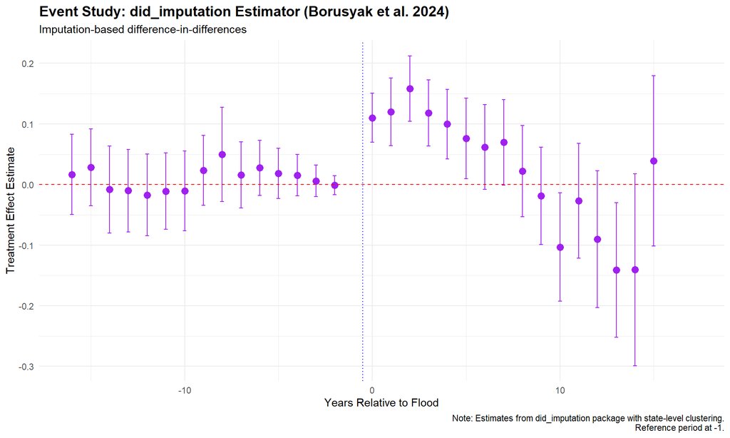

```r
dimp_es_data <- ps2_data %>%
  filter(!is.infinite(treatment_year))

dimp_es_result <- did_imputation(
  data = dimp_es_data,
  yname = "ln_policies",
  gname = "treatment_year",
  tname = "year",
  idname = "id_num",
  first_stage = ~ 0 | id_num + year,
  horizon = TRUE,
  pretrends = TRUE,
  cluster_var = "state"
)

dimp_es_coefs <- dimp_es_result %>%
  as.data.frame() %>%
  filter(!is.na(term)) %>%
  mutate(
    rel_time = as.numeric(gsub(".*[^0-9-]([0-9-]+)$", "\\1", term)),
    conf.low = estimate - 1.96 * std.error,
    conf.high = estimate + 1.96 * std.error
  ) %>%
  arrange(rel_time)

ggplot(dimp_es_coefs, aes(x = rel_time, y = estimate)) +
  geom_point(size = 3, color = "purple") +
  geom_errorbar(aes(ymin = conf.low, ymax = conf.high),
                width = 0.2, color = "purple") +
  geom_hline(yintercept = 0, linetype = "dashed", color = "red") +
  geom_vline(xintercept = -0.5, linetype = "dotted", color = "blue") +
  labs(
    title = "Event Study: did_imputation Estimator (Borusyak et al. 2024)",
    subtitle = "Imputation-based difference-in-differences",
    x = "Years Relative to Flood",
    y = "Treatment Effect Estimate",
    caption = "Note: Estimates from did_imputation package with state-level clustering.\nReference period at -1."
  ) +
  theme_minimal() +
  theme(
    plot.title = element_text(face = "bold", size = 14),
    plot.subtitle = element_text(size = 11),
    axis.title = element_text(size = 11)
  )
```

### Comparison and Discussion

```r
# Create comprehensive comparison table
tibble(
  Method = c("Manual Implementation", "Package (did2s)", "Package (did_imputation)"),
  `ATT Estimate` = c(att_manual$ATT, att_package, att_dimp),
  `Standard Error` = c(att_manual$SE_incorrect, se_package, se_dimp),
  `SE Note` = c("Incorrect (naive)", "Correct (clustered)", "Correct (clustered)")
) %>%
  mutate(across(where(is.numeric), ~round(., 4))) %>%
  kable(caption = "Comparison of ATT Estimates") %>%
  footnote(general = "did2s: Gardner (2021); did_imputation: Borusyak et al. (2024)")
```

Comparison of ATT Estimates

| Method | ATT Estimate | Standard Error | SE Note |
| --- | --- | --- | --- |
| Manual Implementation | 0.0917 | 0.0046 | Incorrect (naive) |
| Package (did2s) | 0.0756 | 0.0367 | Correct (clustered) |
| Package (did_imputation) | 0.0722 | 0.0287 | Correct (clustered) |

Note:  
did2s: Gardner (2021); did_imputation: Borusyak et al. (2024)

```r
# Additional diagnostics
tibble(
  Metric = c("Absolute difference in ATT estimates", "SE ratio (manual/package)"),
  Value = c(
    round(abs(att_manual$ATT - att_package), 4),
    round(att_manual$SE_incorrect / se_package, 2)
  )
) %>%
  kable(caption = "Estimation Diagnostics")
```

Estimation Diagnostics

| Metric | Value |
| --- | --- |
| Absolute difference in ATT estimates | 0.0161 |
| SE ratio (manual/package) | 0.1300 |

**Discussion:**

1. **Do we get the same ATT estimate?**
   - The ATT estimates should be very similar across all three implementations (potentially with small numerical differences due to implementation details)
   - The manual implementation, did2s (Gardner 2021), and did_imputation (Borusyak et al. 2024) all use similar underlying logic: estimate counterfactuals from untreated units
   - did2s and did_imputation are both modern estimators that avoid the “forbidden comparisons” problem in staggered DiD settings
2. **Why are the manual standard errors incorrect?**

   The manual approach (simply taking sd(τ̂)/√n) is incorrect because:
   1. **Estimation uncertainty**: We’re using *estimated* fixed effects (λ̂ᵢ, γ̂ₜ) rather than true values. The simple formula doesn’t account for uncertainty in these first-stage estimates.
   2. **Correlation structure**: Treatment effects τ̂ᵢₜ are not independent - they share common estimated fixed effects, inducing correlation.
   3. **Clustering**: The package correctly accounts for clustering (at state level), which the manual SE ignores.

   The package uses proper asymptotic theory or bootstrap methods to compute standard errors that account for the two-stage estimation procedure.

## Conclusion

This analysis demonstrates the application of modern difference-in-differences methods to study the effect of flood experience on insurance take-up. Key methodological insights: